# Notebook 11 – Solutions

## Getting Started

Before running this notebook, select “Session > Restart R and Clear Output” in the menu above to start a new R session. This will clear any old data sets and give us a blank slate to start with.

## Movies Data

Over the next few classes we will be working with a dataset of movies I have constructed consisting of the top 100 grossing films for each year from 1970 to 2019. The data comes from IMDb. Today we will focus on getting familiar with the various components of the data. Let’s read in the four tables of data, as well as a data dictionary, and then go through each of the tables.

```r
movies <- read_csv(file.path("data", "movies_50_years.csv"))
m_genre <- read_csv(file.path("data", "movies_50_years_genre.csv"))
m_people <- read_csv(file.path("data", "movies_50_years_people.csv"))
m_dict <- read_csv(file.path("data", "movies_50_years_data_dictionary.csv"))
m_color <- read_csv(file.path("data", "movies_50_years_color.csv"))
```

The movies dataset contains one row for each movie. Most of the features are fairly straightforward; you can see the units by opening the data dictionary.

### Movie Genre

Start by making a bar plot showing the number of times each genre tag appears in the dataset. No need for fancy labels or titles, but do order the categories from smallest to largest and consider flipping the axes if your screen is too narrow to read the vertical-bar version of the plot.

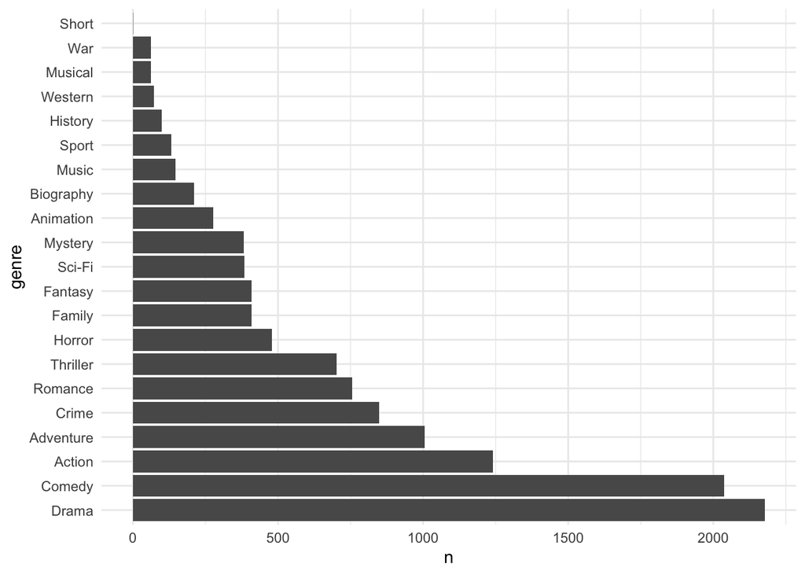

```r
m_genre %>%
  group_by(genre) %>%
  summarize(n = n()) %>%
  arrange(desc(n)) %>%
  mutate(genre = fct_inorder(genre)) %>%
  ggplot(aes(n, genre)) +
    geom_col()
```

Now, we are going to do something a bit more complicated. In the chunk below, create a visualization that shows which genre tag is used the most in each year. The plot is easy; creating the dataset will take some work.

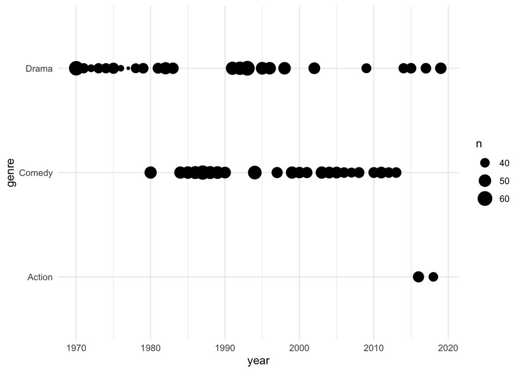

```r
m_genre %>%
  group_by(year, genre) %>%
  summarize(n = n()) %>%
  group_by(year) %>%
  arrange(desc(n)) %>%
  slice(1) %>%
  ggplot(aes(year, genre)) +
    geom_point(aes(size = n))
```

Finally, we are going to create a dataset that has one row for each film that can be merged into the main movies dataset. First, create a dataset that collapses all of the genres for a film into a single value using the function `paste`.

```r
m_genre %>%
  group_by(year, title) %>%
  summarize(genre = paste(genre, collapse = ";"))
```

```
## # A tibble: 4,843 × 3
## # Groups:   year [50]
##     year title                          genre
##    <dbl> <chr>                          <chr>
##  1  1970 ...tick... tick... tick...     Drama;Action
##  2  1970 A Man Called Horse             Adventure;Drama;Western
##  3  1970 A Voyage to Arcturus           Fantasy
##  4  1970 Airport                        Action;Drama;Thriller
##  5  1970 Alex in Wonderland             Comedy;Drama
##  6  1970 Angel Unchained                Action;Thriller;Drama
##  7  1970 Barquero                       Western
##  8  1970 Beneath the Planet of the Apes Action;Adventure;Sci-Fi
##  9  1970 Beyond the Valley of the Dolls Comedy;Drama;Music
## 10  1970 Billy Boy                      Drama;Romance
## # … with 4,833 more rows
```

And then, create a dataset that associates each film to the “least popular” genre associated with it. For example *MASH* is both a comedy, drama, and war film. You should have seen above that the “war” tag is much less common than “comedy” or “drama”, so it should be associated with “war”.

```r
m_genre %>%
  group_by(genre) %>%
  mutate(n = n()) %>%
  arrange(n) %>%
  group_by(year, title) %>%
  slice(1) %>%
  ungroup() %>%   # not needed here, but good practice to ungroup when done
  select(-n)      # also probably do not need `n` anymore, so remove it
```

```
## # A tibble: 4,843 × 3
##     year title                          genre
##    <dbl> <chr>                          <chr>
##  1  1970 ...tick... tick... tick...     Action
##  2  1970 A Man Called Horse             Western
##  3  1970 A Voyage to Arcturus           Fantasy
##  4  1970 Airport                        Thriller
##  5  1970 Alex in Wonderland             Comedy
##  6  1970 Angel Unchained                Thriller
##  7  1970 Barquero                       Western
##  8  1970 Beneath the Planet of the Apes Sci-Fi
##  9  1970 Beyond the Valley of the Dolls Music
## 10  1970 Billy Boy                      Romance
## # … with 4,833 more rows
```

Assigning the least-popular genre typically gives the most appropriate tag to each movie because it will usually also be the most specific genre.

### Movie Color

Start by verifying that the percentage values for each film each add up to 100 (there may be some slight rounding error, but everything should be very close to 100). Use whatever method you find to be the easiest or most reliable, but do not resort to manually checking the values for each film.

```r
m_color %>%
  group_by(year, title) %>%
  summarize(percentage = sum(percentage)) %>%
  ungroup() %>%
  summarize(
    percentage_min = min(percentage),
    percentage_max = max(percentage)
  )
```

```
## # A tibble: 1 × 2
##   percentage_min percentage_max
##            <dbl>          <dbl>
## 1            100            100
```

Next, associate each film to the color that is most dominent in each film poster. Plot a count of the most dominant colors using a bar plot. No need for any labels, titles, or other finishing touches, but do try to color the bars according to the associated color name. Note that you will have to use the aesthetic “fill” and scale `scale_fill_identity` to do this.

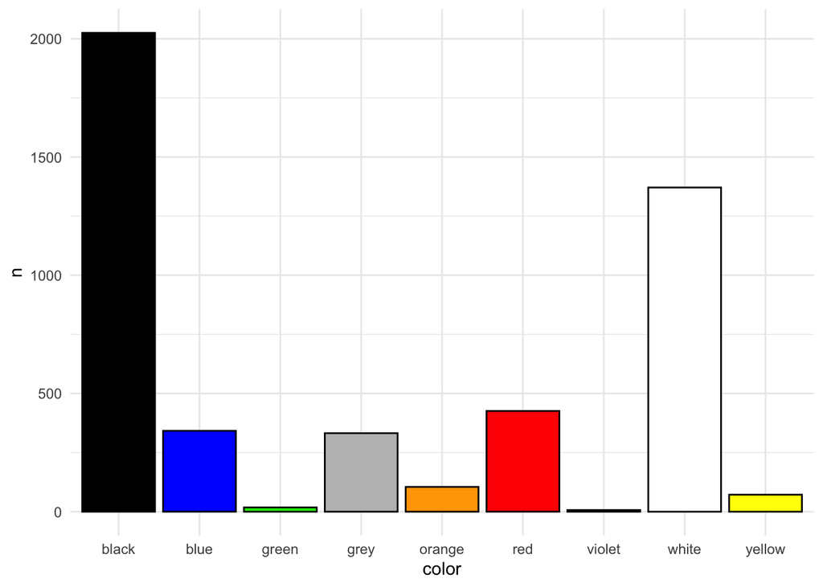

```r
m_color %>%
  group_by(year, title) %>%
  arrange(desc(percentage)) %>%
  slice(1) %>%
  group_by(color) %>%
  summarize(n = n()) %>%
  ggplot(aes(color, n)) +
    geom_col(aes(fill = color), color = "black") +
    scale_fill_identity()
```

Redo the same below, but now include the **two** most dominant colors. Note any patterns that you see in relation to the first plot. Note: this should be any easy tweak of your last plot.

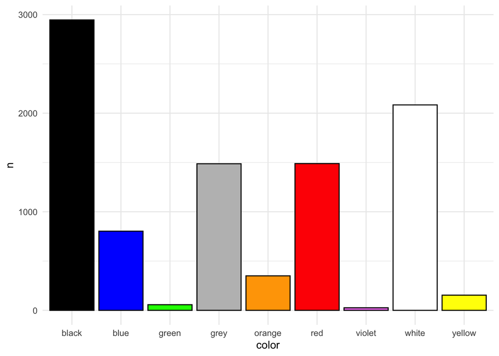

```r
m_color %>%
  group_by(year, title) %>%
  arrange(desc(percentage)) %>%
  slice(1:2) %>%
  group_by(color) %>%
  summarize(n = n()) %>%
  ggplot(aes(color, n)) +
    geom_col(aes(fill = color), color = "black") +
    scale_fill_identity()
```

Finally, filter out just those rows where `color_type` is hue and use a wide pivot to create a dataset with one row per film and a column associated with each color. Pipe this into a plot to show the relationship between the red intensity and the orange intensity.

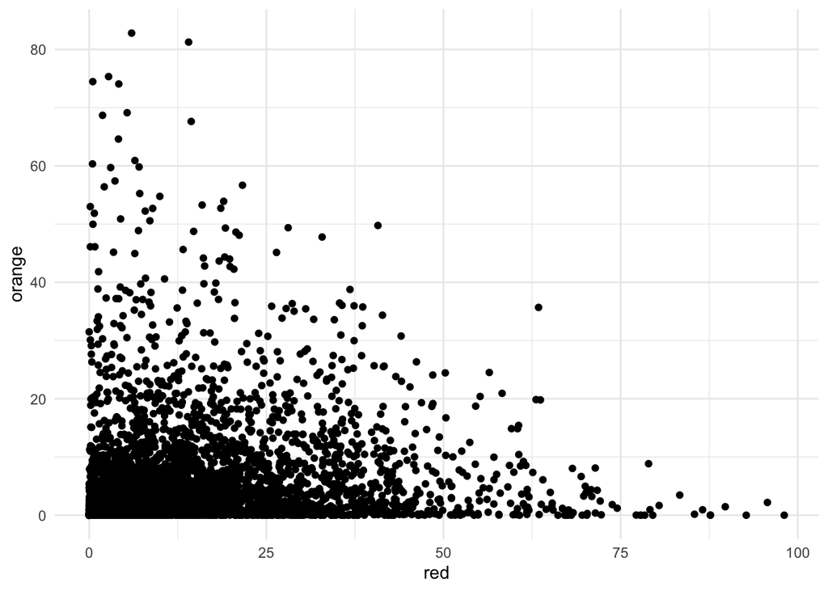

```r
m_color %>%
  filter(color_type == "hue") %>%
  pivot_wider(names_from = "color", values_from = "percentage") %>%
  ggplot(aes(red, orange)) +
    geom_point()
```